# Inital data analysis for FINDONOR- CHANGES IN SELF-RATED HEALTH DURING THE STUDY AND IT’S RELATION TO IRON BIOMARKERS

Mikko Arvas

2020-06-01 15:52:28

# Executive summary

In this file we carry out inital data analysis to decide which explenatory variables to exclude based on correlations between the explenatory variables, shapes of variables distributions and counts of missing data. Then the chosen variables are coded as change between the 2 questionnaires.

# Load the data

We load the data and assign groups as they were assigned in the first part of the study.

```r
#Load questionnaire data
load(file = "../data/final_data.rdata")
data <- data %>% ungroup()
data %>% group_by(questionnaire) %>% count()
```

```
## # A tibble: 2 x 2
## # Groups:   questionnaire [2]
##   questionnaire     n
##   <chr>         <int>
## 1 First          1481
## 2 Second         1481
```

```r
data %>% group_by(questionnaire,group)  %>%  count()
```

```
## # A tibble: 8 x 3
## # Groups:   questionnaire, group [8]
##   questionnaire group                       n
##   <chr>         <fct>                   <int>
## 1 First         Men                       598
## 2 First         Post_menopause_women      362
## 3 First         Pre_menopause_women       483
## 4 First         Women_pre_menop_no_mens    38
## 5 Second        Men                       598
## 6 Second        Post_menopause_women      362
## 7 Second        Pre_menopause_women       483
## 8 Second        Women_pre_menop_no_mens    38
```

```r
data <- data %>% filter(group != 'Women_pre_menop_no_mens')
```

Here are the questions we are processing. See further details from https://onlinelibrary.wiley.com/action/downloadSupplement?doi=10.1111%2Fvox.12856&file=vox12856-sup-0002-SupInfo2.pdf

| Number | Abbreviation | Question text |
| --- | --- | --- |
| 1.1 | HBP | Have you ever been diagnosed with any of the following conditions? Elevated blood pressure |
| 1.2 | cholesterol | Have you ever been diagnosed with any of the following conditions? Elevated cholesterol levels |
| 1.3 | blood_sugar | Have you ever been diagnosed with any of the following conditions? Elevated blood sugar levels |
| 2 | low_hb_hist | Have you ever been diagnosed with a low haemoglobin (Hb) count? |
| 2.1 | anemia_hist | If yes, have you ever been diagnosed with anaemia? |
| 3 | high_hb_hist | Have you ever undergone medical tests because of a high haemoglobin count? |
| 4 | anti_inf | During the past four weeks, have you taken anti-inflammatory pain medication (such as aspirin, ibuprofen or ketoprofen)? |
| 5 | health | How would you rate your recent health in general? |
| 6 | health_c | How would you rate your health compared with other people of similar age? |
| 7.1 | act_light | Based on your health, how would you rate your ability to carry out the following daily activities? A. Light chores, such as moving a table, vacuuming or cycling. |
| 7.2 | act_heavy | Based on your health, how would you rate your ability to carry out the following daily activities? B. Climbing several flights of stairs |
| 8 | phys_inf | During the past four weeks, have your physical symptoms (such as pain) or health in general interfered with your work or other daily activities? |
| 9 | ment_inf | During the past four weeks, has your mental health interfered with your work or other daily activities? |
| 10 | accomplish | Have you felt that you were able to accomplish less than you would have liked to? |
| 11.A | freq_calm | During the past four weeks, how often have you felt: calm and relaxed? |
| 11.B | freq_energy | During the past four weeks, how often have you felt: full of energy? |
| 11.C | freq_sad | During the past four weeks, how often have you felt: sad? |
| 12 | health_soc | During the past four weeks, how often has your physical or emotional health interfered with your social activities (such as visiting friends or relatives)? |
| 13.A | sleep_night | How many hours do you sleep on average A. per night (round to the nearest half hour)? |
| 13.B | sleep_24h | How many hours do you sleep on average B. over a 24-hour period, including nights and daytime naps (round to the nearest half hour)? |
| 14.A | sleep_enough | Sleep habits A. Do you think you get enough sleep? |
| 14.B | sleep_tired | Sleep habits B. Do you feel tired during the day? |
| 15.A | vita_multi | During the past four weeks, have you taken A. multivitamin tablets/supplements? |
| 15.B | vita_C | During the past four weeks, have you taken B. vitamin C tablets/supplements? |
| 15.C | vita_iron | During the past four weeks, have you taken C. iron tablets/supplements? |
| 16 | iron_supp | Were you given iron tablets when you last donated blood? |
| 16.1 | iron_supp_detailed | If yes, how many iron tablets did you take? |
| 17 | diet | Do you follow a special diet? |
| 18.A | freq_red_meat | How often do you have A. red meat (beef, pork, lamb, game) as the main course? |
| 18.B | freq_cutlets | How often do you have B. cutlets? |
| 18.C | freq_fish | How often do you have C. fish? |
| 18.D | freq_eggs | How often do you have D. eggs? |
| 18.E | freq_fruits | How often do you have E. fruit and berries? |
| 18.F | freq_vege | How often do you have F. salad and vegetables? |
| 18.G | freq_juices | How often do you have G. fruit juices? |
| 18.H | freq_wholem | How often do you have H. wholemeal products (such as porridge, bread, muesli)? |
| 19.A | freq_milk | How often do you have A. milk or other dairy products? |
| 19.B | freq_cof | How often do you have B. coffee? |
| 19.C | freq_tea | How often do you have C. tea? |
| 19.D | freq_beer | How often do you have D. beer? |
| 19.E | freq_wine | How often do you have E. wine? |
| 19.F | freq_spirits | How often do you have F. spirits? |
| 20 | smoking | Do you smoke? |
| 21 | phys_cond | How would you rate your current physical condition? |
| 22 | day_act | Which of the following statements best describes your typical day (work, studies, leisure)? |
| 23 | h_act_light | On average, how much time do you spend each day doing light everyday physical activity, such as cycling, walking or rollerblading? Tick the alternative that best describes the average time… |
| 24 | freq_sports | How often do you exercise/do sports in your free time? |
| 26 | h_act_none | On average, how long do you spend each day in your free time on activities that are sedentary (such as doing handicrafts, reading, watching television, playing computer games, surfing the … |
| S1 | life_qual | How would you rate your quality of life? |
| S2 | education | What is the highest level of education you have attained? |
| S3 | employment | Employment status |

# Remove end point variable

In the inital data analysis stage we do not want to look at our primary endpoint question 5 “How would you rate your recent health in general?” i.e. “health” to avoid fishing for correlations.

```r
temp <- data %>% dplyr::select(donor,health) %>% filter(is.na(health))
data <- data %>% filter(!donor %in% unique(temp$donor))  %>% dplyr::select(-health)
data %>% group_by(questionnaire) %>% count()
```

```
## # A tibble: 2 x 2
## # Groups:   questionnaire [2]
##   questionnaire     n
##   <chr>         <int>
## 1 First          1438
## 2 Second         1438
```

### Remove donors with extreme physiological measures

As decided previously, we remove data according the following criteria:

- CRP >= 30
- Ferritin >= 400

```r
#Rename because next file will also bring an object called data
qdata <-data
#load measurement data
load(file = "../data/quest_2_donor_data.rdata")

data <- data %>%
  rename(Ferritin_beginning = Ferritin,
         CRP_beginning = CRP) %>% dplyr::select(donor,Ferritin_beginning,CRP_beginning) %>% inner_join(qdata)
cat(nrow(data)/2,"\n")
```

```
## 1438
```

```r
data <- data %>%   filter(Ferritin_beginning < 400)
cat(nrow(data)/2,"after high ferritin removal\n")
```

```
## 1435 after high ferritin removal
```

```r
data <- data %>%   filter(CRP_beginning < 30)
cat(nrow(data)/2,"after high CRP removal\n")
```

```
## 1431 after high CRP removal
```

```r
data <- data %>% ungroup()
```

```r
data <- data %>% dplyr::select(-Ferritin_beginning,-CRP_beginning)
data %>% group_by(questionnaire) %>% count()
```

```
## # A tibble: 2 x 2
## # Groups:   questionnaire [2]
##   questionnaire     n
##   <chr>         <int>
## 1 First          1431
## 2 Second         1431
```

# Preprocessing recodings

Questions with 3 possible answers : “no”, “yes”, “don’t know”, are recoded as an ordered factor with 3 levels: “yes”< “don’t know” < “no”.

```r
#Have you felt that you were able to accomplish less than you would have liked to?
temp <- as.character(data$accomplish)
temp[is.na(temp)] <- "don't know"
data$accomplish = ordered(temp,
                levels =  c("yes","don't know", "no"))
#During the past four weeks, has your mental health interfered with your work or other daily activities?
##Later in explorative_analysis.Rmd we find out that some variables cannot be fitted. We remove them now not to loose data over them
# temp <- as.character(data$ment_inf)
# temp[is.na(temp)] <- "don't know"
# data$ment_inf = ordered(temp,
#                 levels =  c("yes","don't know", "no"))

#During the past four weeks, have your physical symptoms (such as pain) or health in general interfered with your work or other daily activities?
temp <- as.character(data$phys_inf)
temp[is.na(temp)] <- "don't know"
data$phys_inf = ordered(temp,
                levels =  c("yes","don't know", "no"))
```

# How much data do we have

```r
#Save questions only asked in the second questionaire to be added back later.
additionalq <- data %>% filter(questionnaire == "Second") %>% dplyr::select(donor, life_qual, education, employment)
#drop out variables that,
# we know from our previous work are too messy: iron_supp_detailed
# were only asked in second questionaire: life_qual, education, employment
# are conveniency variables: AgeGroup, SixMonthsFromStartCount_FB, TwoYearsFromStartCount_FB
temp <- data %>% dplyr::select(-iron_supp_detailed, -life_qual, -education, -employment,-AgeGroup, -SixMonthsFromStartCount_FB,-TwoYearsFromStartCount_FB)

#

temp <- na.omit(temp)
table(table(temp$donor))
```

```
##
##   1   2
## 492 817
```

817 donors with complete data in both questionaires.

```r
temp %>% group_by(questionnaire) %>%  count()
```

```
## # A tibble: 2 x 2
## # Groups:   questionnaire [2]
##   questionnaire     n
##   <chr>         <int>
## 1 First          1038
## 2 Second         1088
```

As we will loose almost half of our data if we study only complete data we have try to make decisions on which questions to exclude prior to analyses or which data to impute.

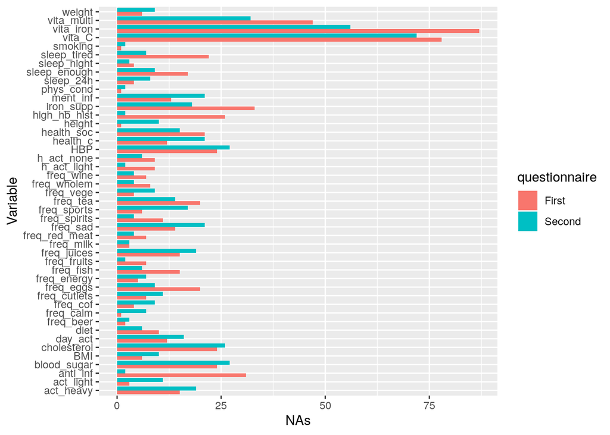

```r
temp <- data %>% dplyr::select(-iron_supp_detailed, -life_qual, -education, -employment,-AgeGroup, -SixMonthsFromStartCount_FB,-TwoYearsFromStartCount_FB,-donor)
temp <- temp %>% group_by(questionnaire) %>%  summarise_all(funs(sum(is.na(.))))
temp <- as_tibble(t(temp), rownames = "Variable") %>% filter(Variable != "questionnaire")
colnames(temp)[2] <- "First"
colnames(temp)[3] <- "Second"
temp <- temp %>%  gather(key="questionnaire",value="NAs",-Variable) %>% mutate(NAs = as.numeric(gsub(" ","",NAs))) %>% filter(NAs != 0)

ggplot(temp) + geom_col(aes(x=Variable,y=NAs,fill=questionnaire),pos="dodge") +  coord_flip()
```

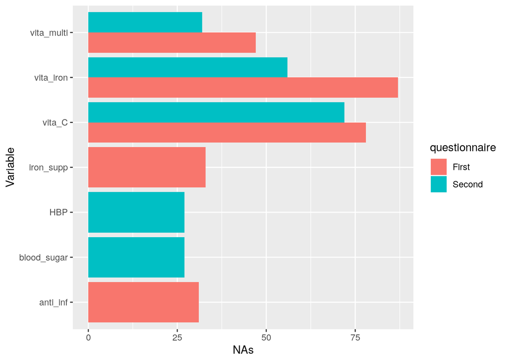

```r
temp <- temp %>% arrange(NAs) %>% tail(10)

ggplot(temp) + geom_col(aes(x=Variable,y=NAs,fill=questionnaire),pos="dodge") +  coord_flip()
```

People cannot remember if they have taken vitamine supplements containing iron or vitamine C. Let’s first see if some of these will drop out because they correlate heavily with some other explenatory variable.

# Correlations between variables

```r
temp <- data %>% dplyr::select(-iron_supp_detailed, -life_qual, -education, -employment,-AgeGroup, -SixMonthsFromStartCount_FB,-TwoYearsFromStartCount_FB, -donor,-questionnaire,-sex,-group)
temp$date <- as.numeric(temp$date)

#Change the numeric to factors to enable similar correlation calculation for all
temp <- temp %>% mutate_if(is.numeric, ~cut(.,5))

#https://datascience.stackexchange.com/questions/893/how-to-get-correlation-between-two-categorical-variable-and-a-categorical-variab
cormat <- matrix(NA,ncol = ncol(temp),nrow=ncol(temp))
rownames(cormat) <-colnames(temp)
colnames(cormat) <-colnames(temp)
for (i in rownames(cormat)) {
  for (j in colnames(cormat)) {
    d <- table(as.factor(temp[[i]]),as.factor(temp[[j]]))
#    print(d)
    #drop any all zero rows
    d <- d[apply(X=d,MARGIN = 1,FUN = function(x){!all(x == 0 )}),]
    d <- d[,apply(X=d,MARGIN = 2,FUN = function(x){!all(x == 0 )})]
    #print(d)
    t <- chisq.test(d,correct = F)
    cramersV <- sqrt(t$statistic / sum(d))
    if (cramersV > 1) {
      #sometimes it fails in perfect correlation
      cramersV <- 1
    }
    cormat[i,j] <- cramersV
  }
}
```

Visualise correlation disribution

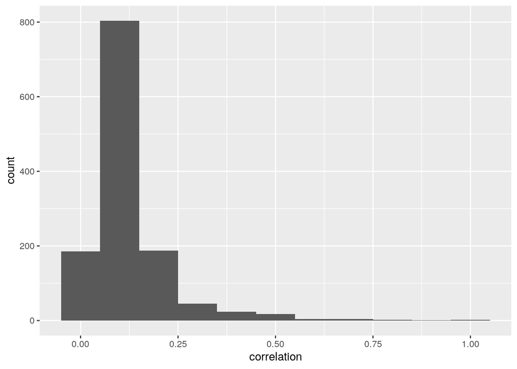

```r
temp <- data.frame(correlation=cormat[lower.tri(cormat)])
ggplot(temp) +  geom_histogram(aes(x=correlation),binwidth = 0.1)
```

```r
#and create a fake significance matrix of arbitary correlation of 0.5
p.mat <- matrix(1, nrow=nrow(cormat),ncol=ncol(cormat))
p.mat[as.vector(cormat > 0.5)] <- 0.01
diag(p.mat) <- 1
```

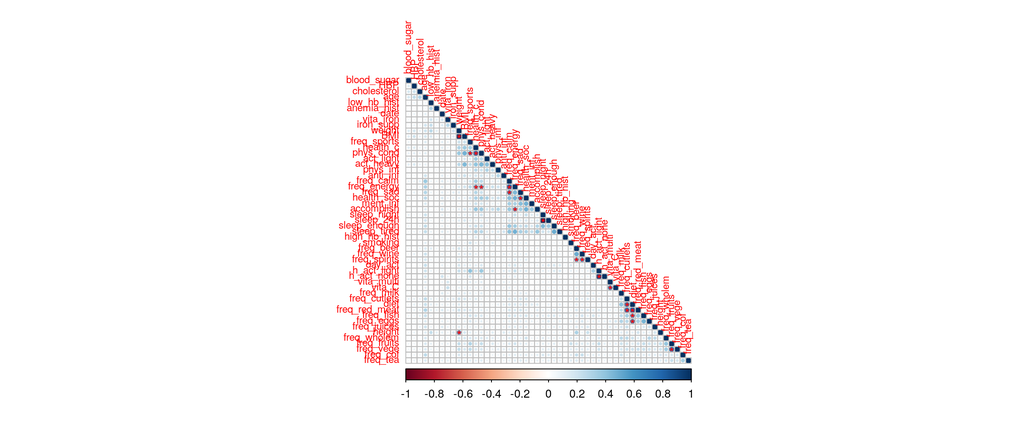

```r
corrplot(cormat,type="lower",order="hclust",p.mat=p.mat,sig.level = 0.05,insig = "label_sig",pch.col = 'red',pch.cex = 1,mar = c(1, 1, 4, 1),xpd=TRUE,tl.cex=0.7)
```

```r
pdf("../results/figures/IDAcorrplotFull.pdf",width = 10,height = 10)
corrplot(cormat,type="lower",order="hclust",p.mat=p.mat,sig.level = 0.05,insig = "label_sig",pch.col = 'red',pch.cex = 1,mar = c(1, 1, 4, 1),xpd=TRUE,tl.cex=0.7)
dev.off()
```

Extract those with correlation above 0.5.

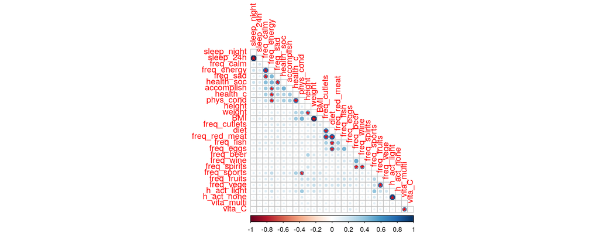

```r
#take anything with at least 0.5 correlation
any_above <- function(x){any(x > 0.5) }
temp <-cormat
#empty the diagonal
diag(temp) <- 0
#filter fake significance matrix
temp2 <- p.mat[apply(temp,1, any_above),apply(temp,2, any_above)]
#filter correlation matrix
temp <- temp[apply(temp,1, any_above),apply(temp,2, any_above)]



corrplot(temp,type="lower",order="hclust",p.mat=temp2,sig.level = 0.05,insig = "label_sig",pch.col = 'red',pch.cex = 1.5,mar = c(1, 1, 4, 1),xpd=TRUE,tl.cex=1 )
```

```r
pdf("../results/figures/IDAcorrplotFiltered.pdf",width = 8,height = 8)
corrplot(temp,type="lower",order="hclust",p.mat=temp2,sig.level = 0.05,insig = "label_sig",pch.col = 'red',pch.cex = 1.5,mar = c(1, 1, 4, 1),xpd=TRUE,tl.cex=1 )
dev.off()
```

# Choose what to keep

Between those that correlate above 0.5 choose which variable to keep to present the correlaiting variables in the exploratory analysis.

## act_light, act_heavy

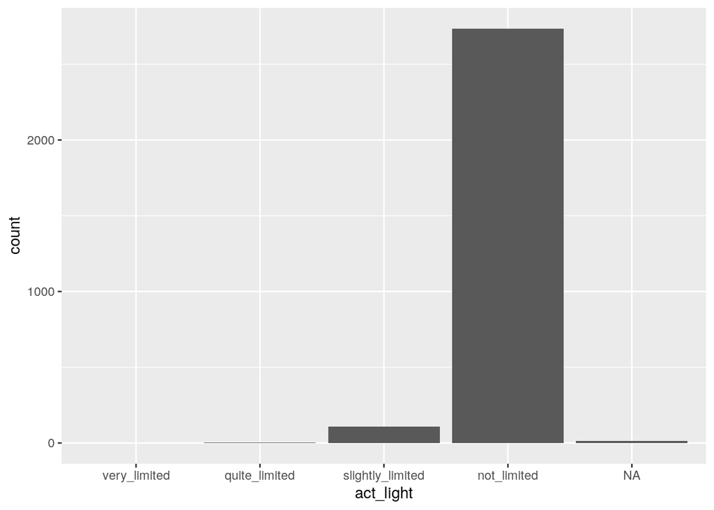

```r
ggplot(data) + geom_bar(aes(x=act_light))
```

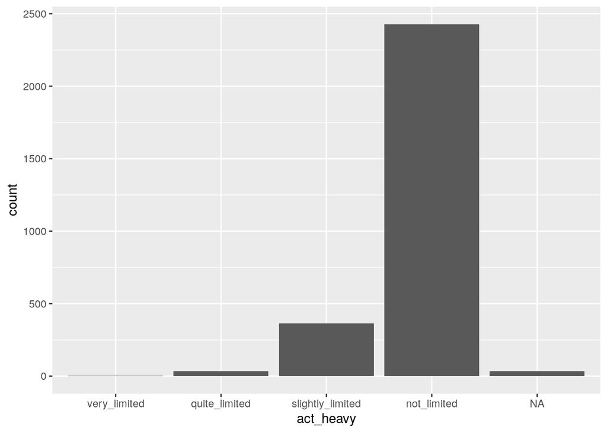

```r
ggplot(data) + geom_bar(aes(x=act_heavy))
```

```r
table(is.na(data$act_heavy))
```

```
##
## FALSE  TRUE
##  2828    34
```

```r
table(is.na(data$act_light))
```

```
##
## FALSE  TRUE
##  2848    14
```

act_heavy looses more data, but has much more spread pontentially contaning more information.

Keep “act_heavy”.

## health_c vs phys_cond

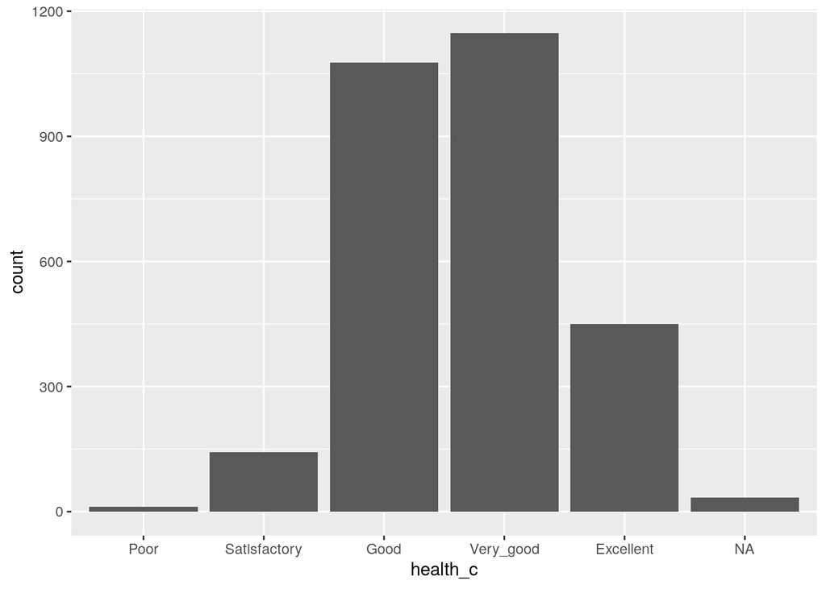

```r
ggplot(data) + geom_bar(aes(x=health_c))
```

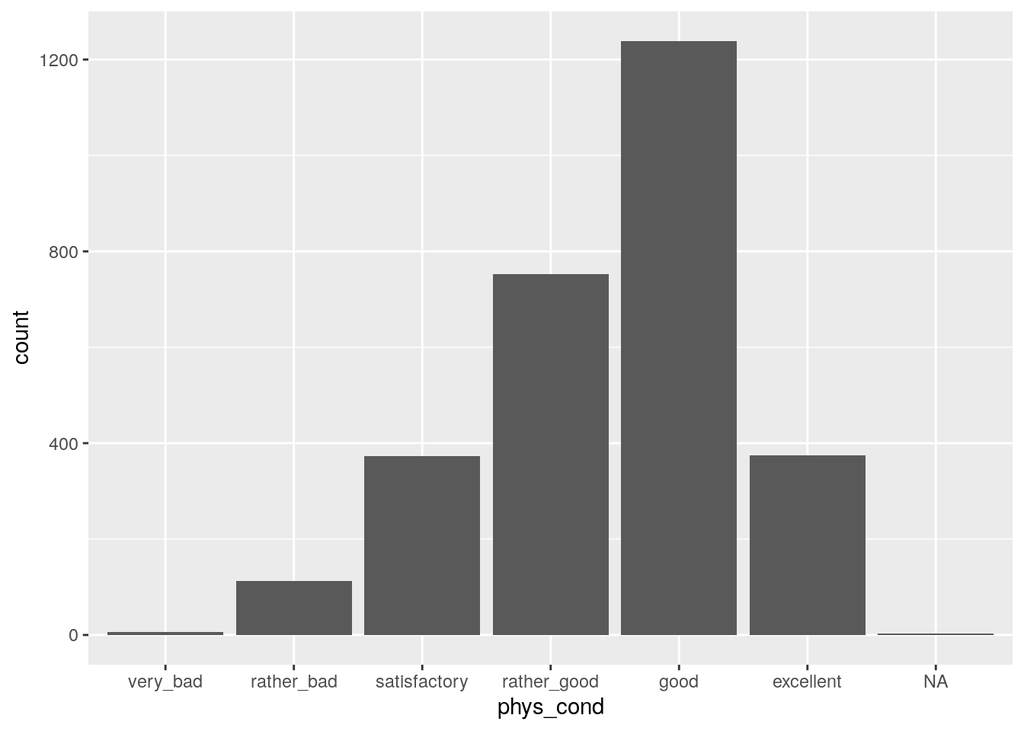

```r
ggplot(data) + geom_bar(aes(x=phys_cond))
```

```r
#Notice that this has been already set from worst to best unlike in the original questionaire
```

```r
table(is.na(data$health_c))
```

```
##
## FALSE  TRUE
##  2829    33
```

```r
table(is.na(data$phys_cond))
```

```
##
## FALSE  TRUE
##  2859     3
```

phys_cond looks better and looses less data.

## vita_c vs vita_multi

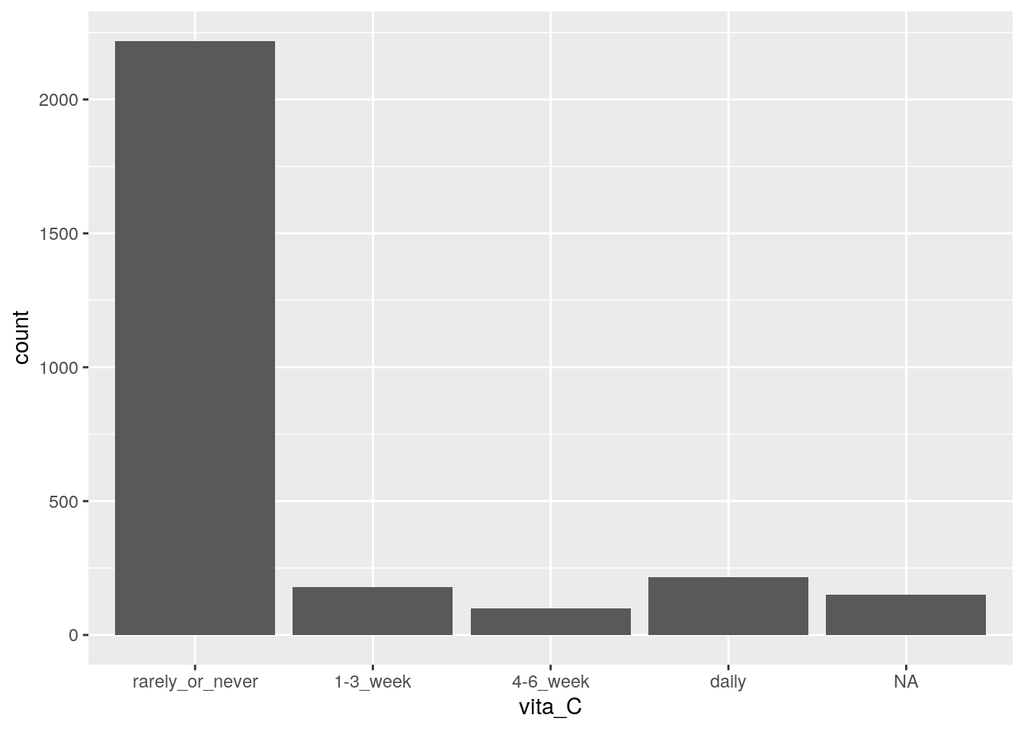

```r
ggplot(data) + geom_bar(aes(x=vita_C))
```

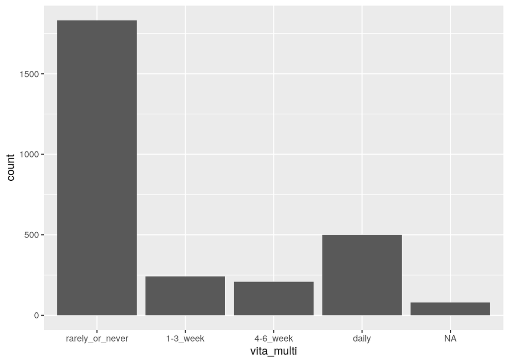

```r
ggplot(data) + geom_bar(aes(x=vita_multi))
```

```r
table(is.na(data$vita_C))
```

```
##
## FALSE  TRUE
##  2712   150
```

```r
table(is.na(data$vita_multi))
```

```
##
## FALSE  TRUE
##  2783    79
```

vita_multi looses much less data and looks better so vita_C can be dropped.

## sleep_night vs sleep_24h

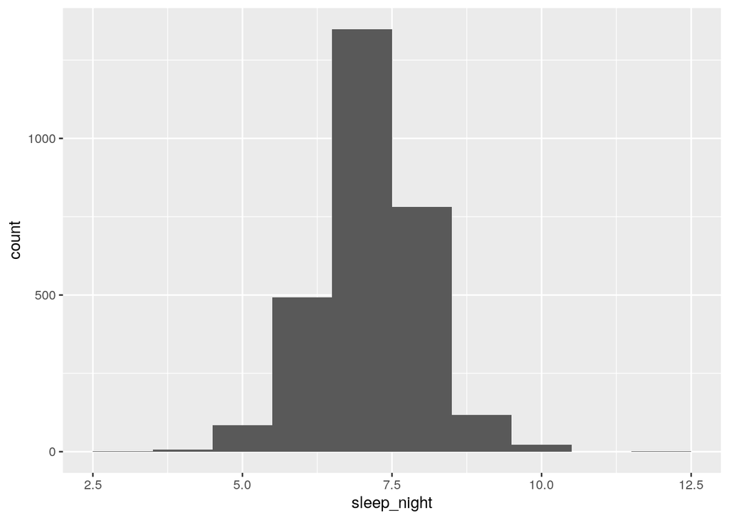

```r
ggplot(data) + geom_histogram(aes(x=sleep_night),binwidth = 1)
```

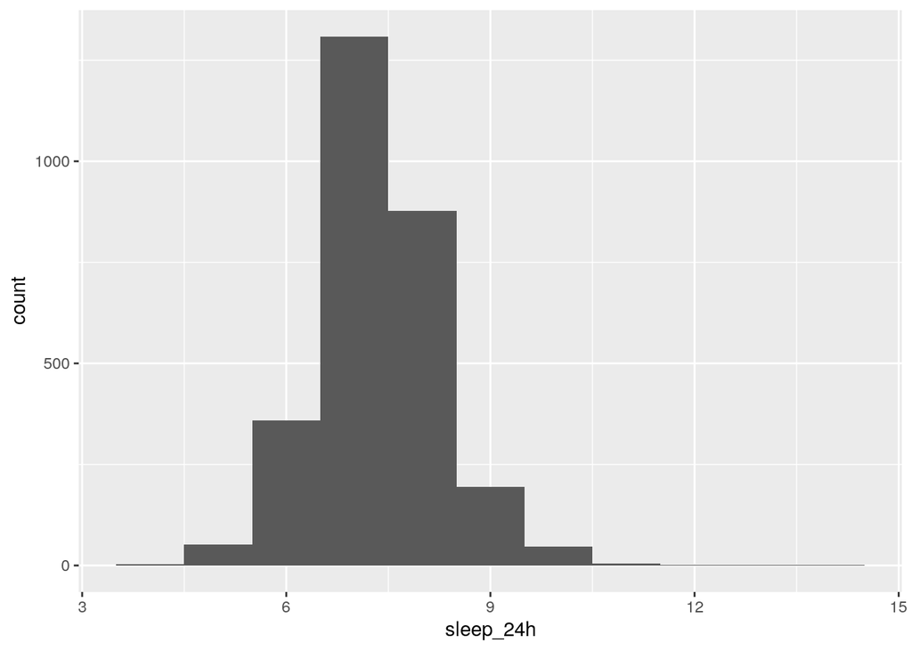

```r
ggplot(data) + geom_histogram(aes(x=sleep_24h),binwidth = 1)
```

```r
table(is.na(data$sleep_night))
```

```
##
## FALSE  TRUE
##  2855     7
```

```r
table(is.na(data$sleep_24h))
```

```
##
## FALSE  TRUE
##  2850    12
```

Distributions look quite similar, but sleep_night looses less data.

## freq_fruits vs freq_vege

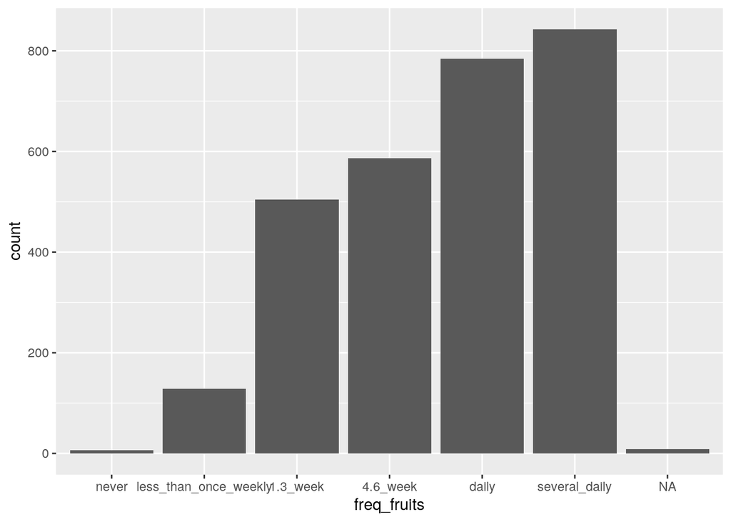

```r
ggplot(data) + geom_bar(aes(x=freq_fruits))
```

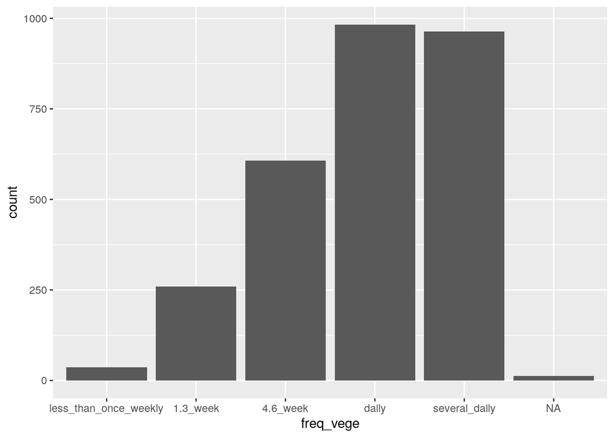

```r
ggplot(data) + geom_bar(aes(x=freq_vege))
```

```r
table(is.na(data$freq_fruits))
```

```
##
## FALSE  TRUE
##  2853     9
```

```r
table(is.na(data$freq_vege))
```

```
##
## FALSE  TRUE
##  2849    13
```

freq_fruits look better and looses less data.

## freq_sports vs phys_cond

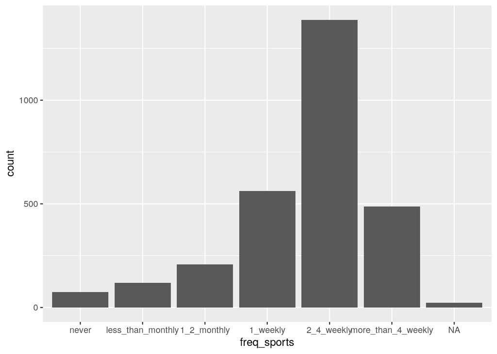

```r
ggplot(data) + geom_bar(aes(x=freq_sports))
```

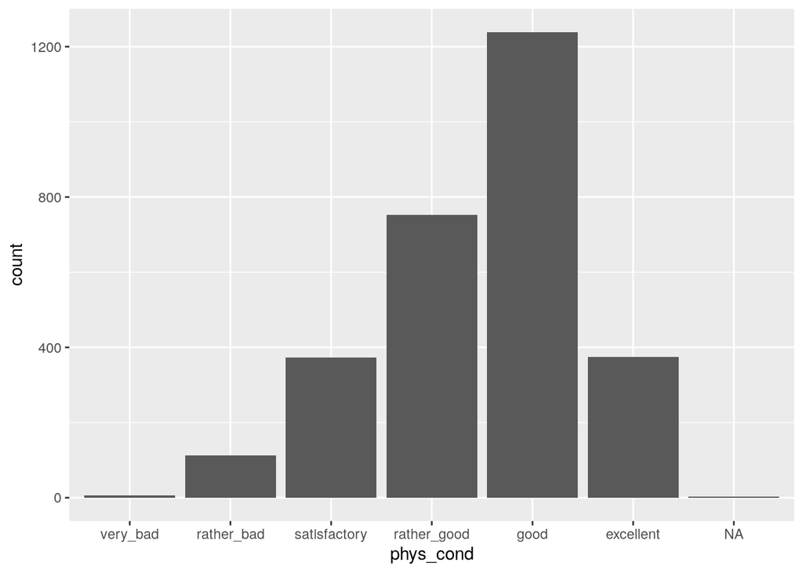

```r
ggplot(data) + geom_bar(aes(x=phys_cond))
```

```r
table(is.na(data$freq_sports))
```

```
##
## FALSE  TRUE
##  2839    23
```

```r
table(is.na(data$phys_cond))
```

```
##
## FALSE  TRUE
##  2859     3
```

Hard to say anything about the distributions, but physical condition looses less data.

## freq_spirits, freq_beer, freq_wine

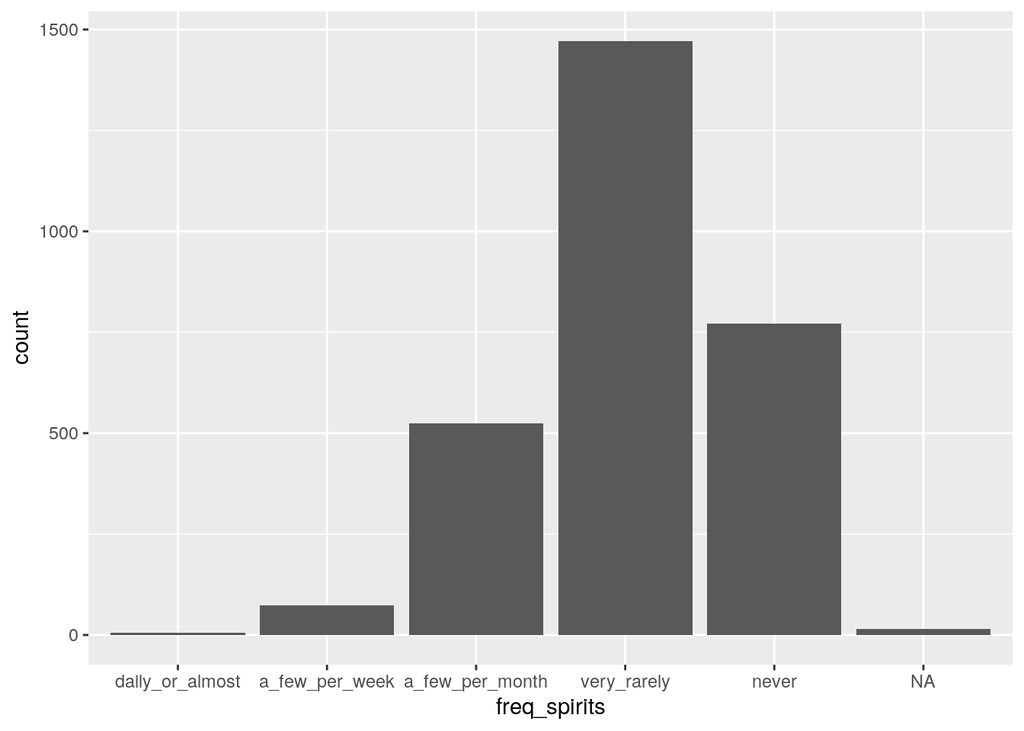

```r
ggplot(data) + geom_bar(aes(x=freq_spirits))
```

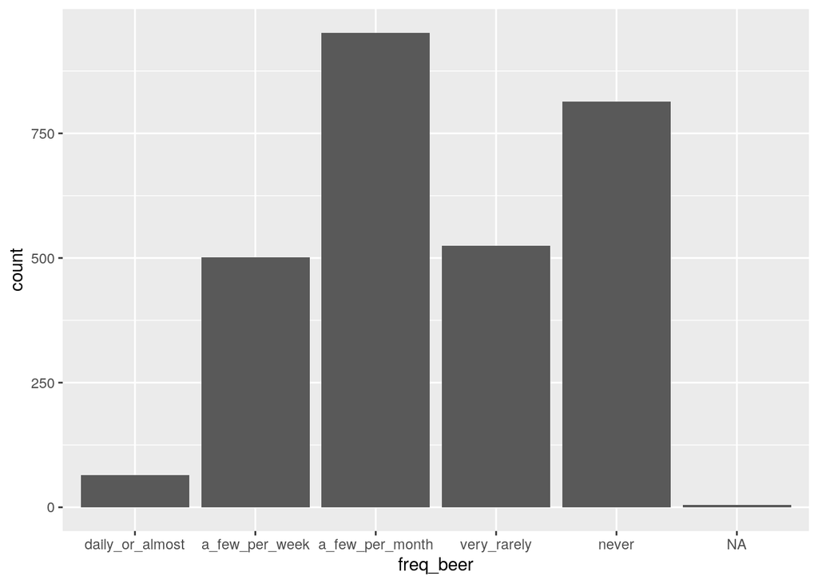

```r
ggplot(data) + geom_bar(aes(x=freq_beer))
```

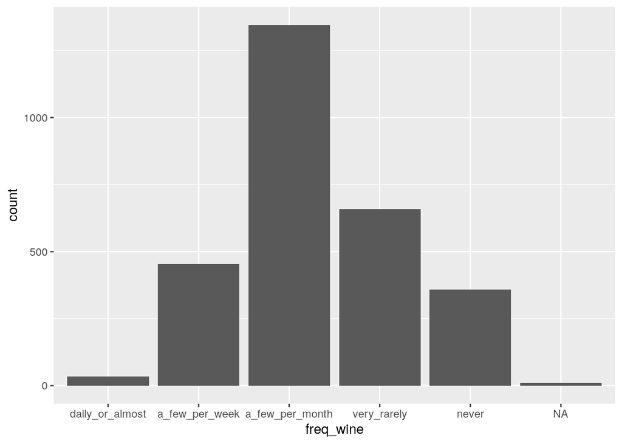

```r
ggplot(data) + geom_bar(aes(x=freq_wine))
```

```r
table(is.na(data$freq_spirits))
```

```
##
## FALSE  TRUE
##  2847    15
```

```r
table(is.na(data$freq_beer))
```

```
##
## FALSE  TRUE
##  2857     5
```

```r
table(is.na(data$freq_wine))
```

```
##
## FALSE  TRUE
##  2851    11
```

Hard to say, but freq_beer looses least data. But this does not cover at all persons that drink mostly cider which could be in particular found in pre-menopausal women.

To have have some kind of proxy over these incomplete but overlapping questions we will create a new variable freq_alc.

```r
#Combine the alcohol questions
data$freq_alc <- as.ordered(apply(cbind(data$freq_beer,data$freq_wine,data$freq_spirits),1,max,na.rm=TRUE))
#Make it in to a factor
levels(data$freq_alc) <- levels(data$freq_beer)
```

## freq_cutlets, freq_meat, diet, freq_meat, freq_fish, freq_eggs

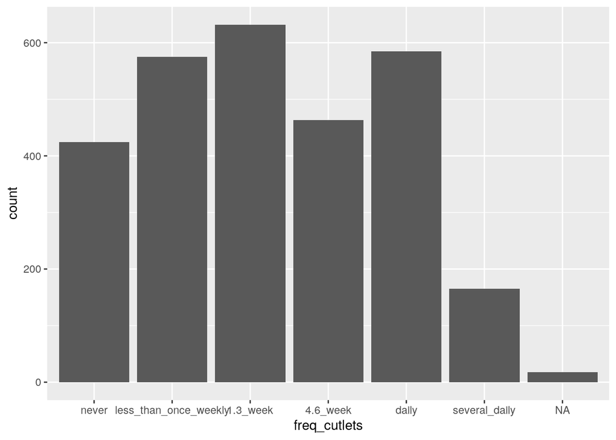

```r
ggplot(data) + geom_bar(aes(x=freq_cutlets))
```

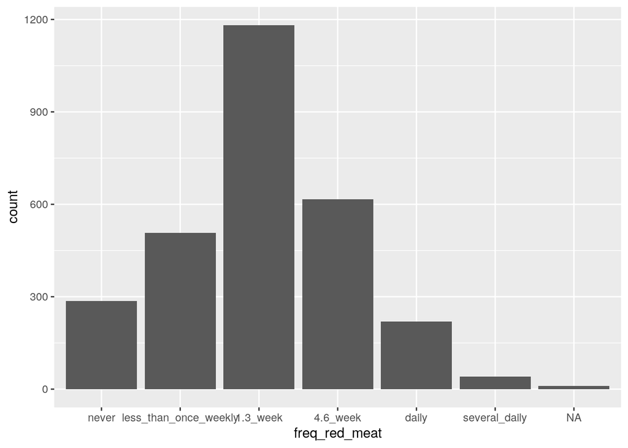

```r
ggplot(data) + geom_bar(aes(x=freq_red_meat))
```

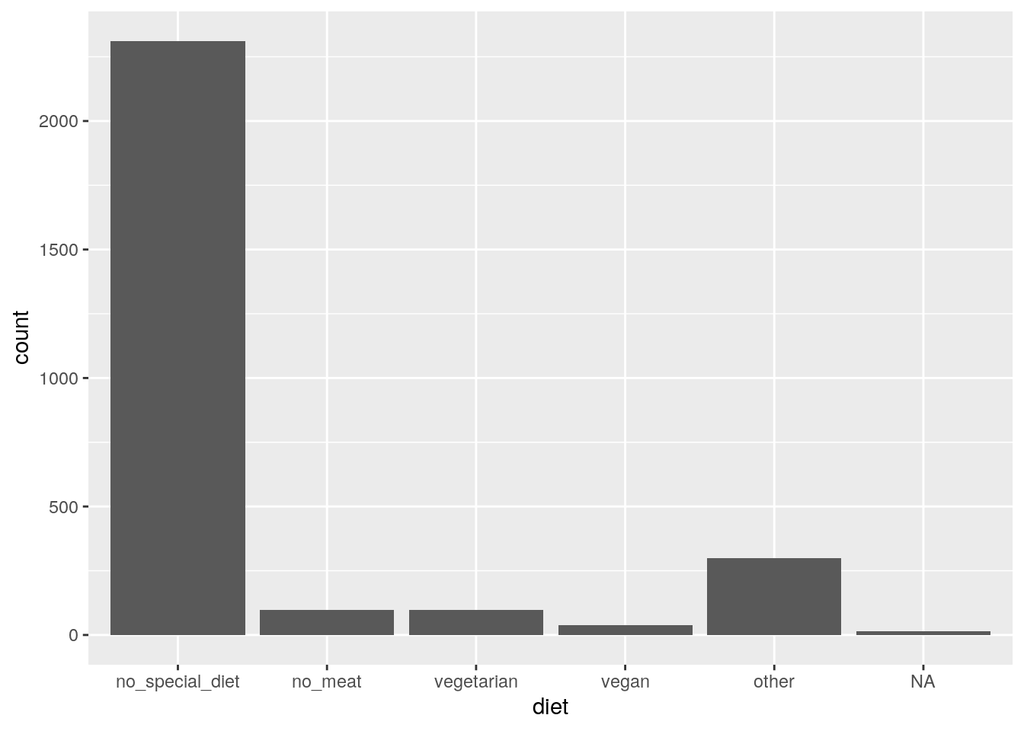

```r
ggplot(data) + geom_bar(aes(x=diet))
```

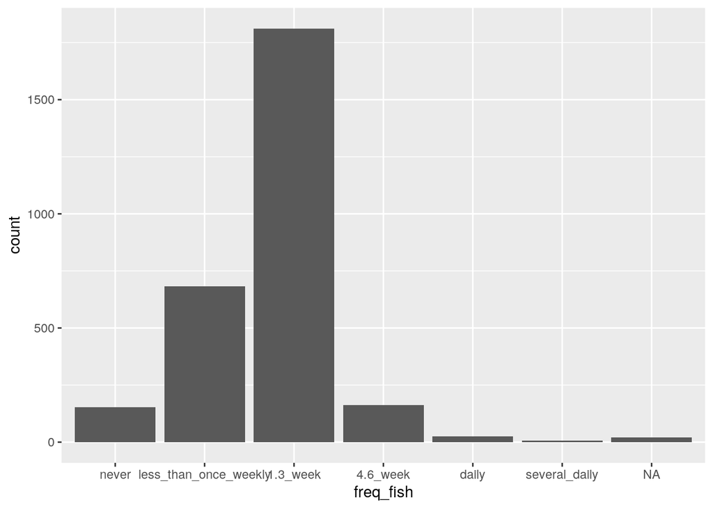

```r
ggplot(data) + geom_bar(aes(x=freq_fish))
```

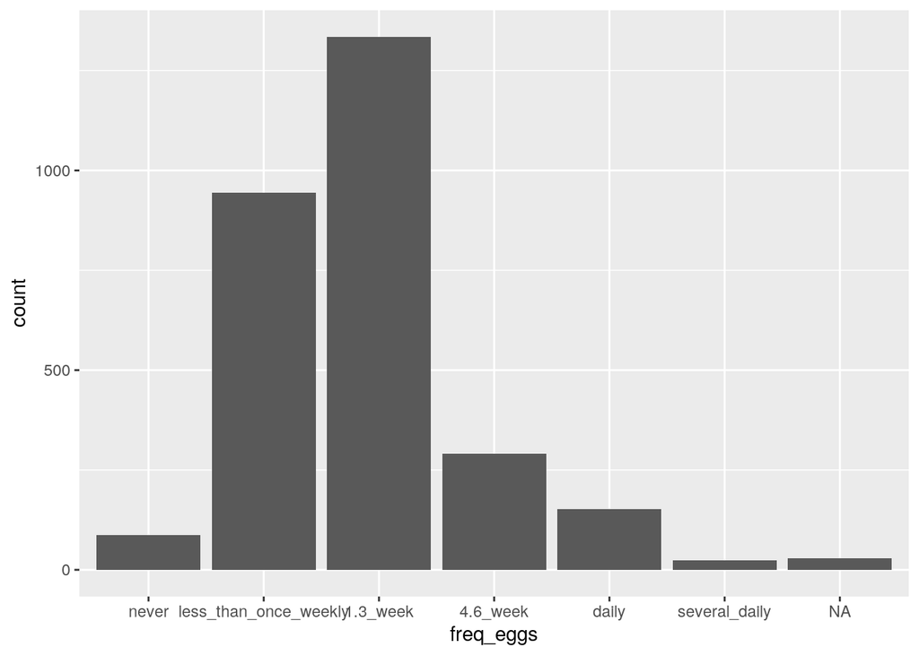

```r
ggplot(data) + geom_bar(aes(x=freq_eggs))
```

```r
table(is.na(data$freq_cutlets))
```

```
##
## FALSE  TRUE
##  2844    18
```

```r
table(is.na(data$freq_red_meat))
```

```
##
## FALSE  TRUE
##  2851    11
```

```r
table(is.na(data$diet))
```

```
##
## FALSE  TRUE
##  2846    16
```

```r
table(is.na(data$freq_fish))
```

```
##
## FALSE  TRUE
##  2841    21
```

```r
table(is.na(data$freq_eggs))
```

```
##
## FALSE  TRUE
##  2833    29
```

As already seen in the enrollment data paper freq_red_meats distribution looks best also it looses leas data.

## BMI, height and weigth

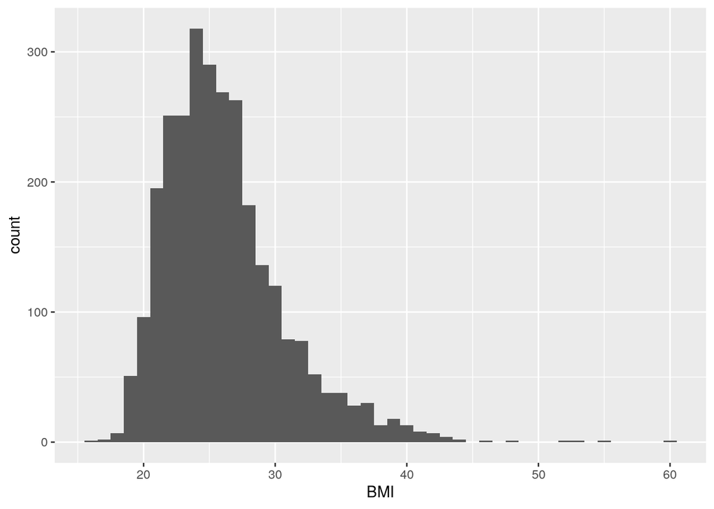

```r
ggplot(data) + geom_histogram(aes(x=BMI),binwidth = 1)
```

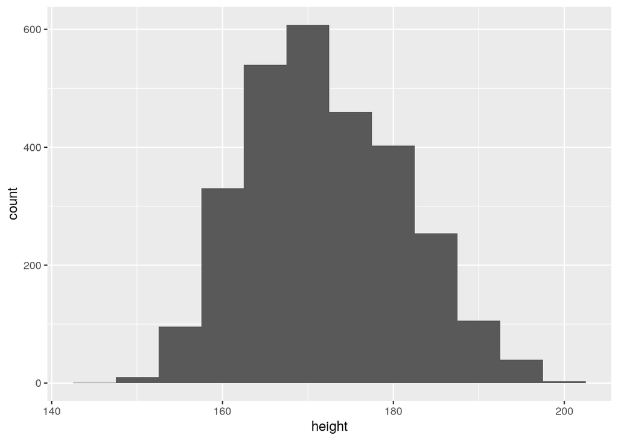

```r
ggplot(data) + geom_histogram(aes(x=height),binwidth = 5)
```

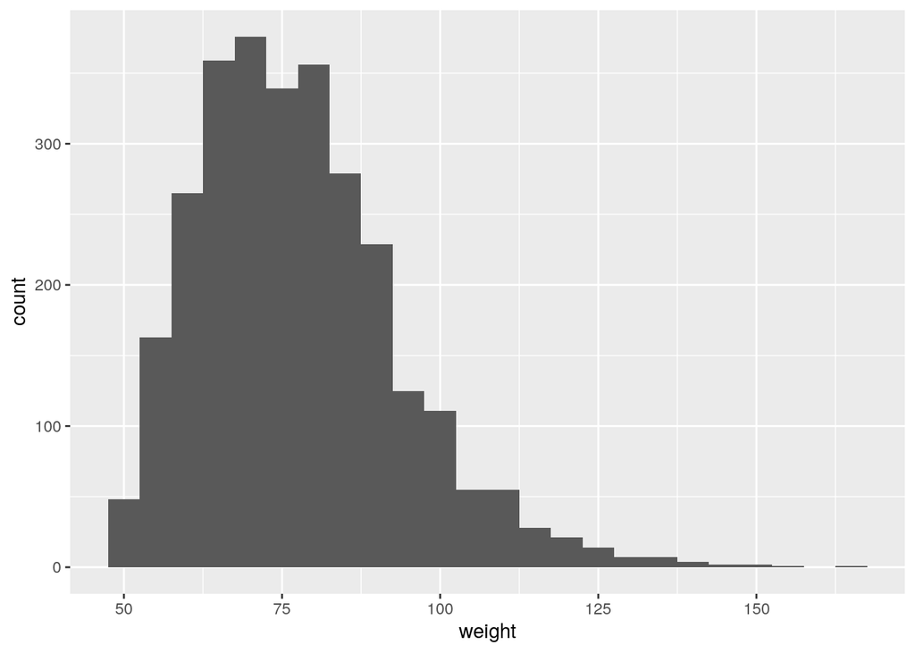

```r
ggplot(data) + geom_histogram(aes(x=weight),binwidth = 5)
```

```r
table(is.na(data$BMI))
```

```
##
## FALSE  TRUE
##  2846    16
```

```r
table(is.na(data$height))
```

```
##
## FALSE  TRUE
##  2851    11
```

```r
table(is.na(data$weight))
```

```
##
## FALSE  TRUE
##  2847    15
```

Keep BMI as composite of both.